# BME1510 Assignment 2: Data Visualization with Iris Dataset

Load the dataset "iris". Answer the following questions using visualizations only:

1. What is the median petal length for each iris species?
2. What is the mean sepal width for each iris species?
3. Is there an association between sepal length and width?
4. Compare the distributions of petal width for each species.
5. Are there any petal length outliers?
6. Does the association between pedal and sepal width change with pedal length?

# Authors: Malek Sibai, Mahri Kadyrova

```python
# !pip install ipykernel
```

```python
!pip install seaborn
!pip install matplotlib
!pip install pandas
!pip install numpy
!pip install scipy
!pip install scikit-learn
!pip install scikit-learn
```

```python
# Import libraries
import seaborn as sns
import matplotlib.pyplot as plt
import pandas as pd

# Set seaborn theme for better-looking plots
sns.set_theme(context='notebook', style='darkgrid', palette='deep')
```

```python
# Load the iris dataset
iris = sns.load_dataset('iris')

# Display first few rows to understand the data
iris.head()
```

|  | sepal_length | sepal_width | petal_length | petal_width | species |
| --- | --- | --- | --- | --- | --- |
| 0 | 5.1 | 3.5 | 1.4 | 0.2 | setosa |
| 1 | 4.9 | 3.0 | 1.4 | 0.2 | setosa |
| 2 | 4.7 | 3.2 | 1.3 | 0.2 | setosa |
| 3 | 4.6 | 3.1 | 1.5 | 0.2 | setosa |
| 4 | 5.0 | 3.6 | 1.4 | 0.2 | setosa |

## Question 1: What is the median petal length for each iris species?

A box plot was used in this question as it provides the info of the minimum, median, and maximum. This would be the graph that enables to find the medium for each species and allow it to do a very clear side by side comparison of the median for each of those species.

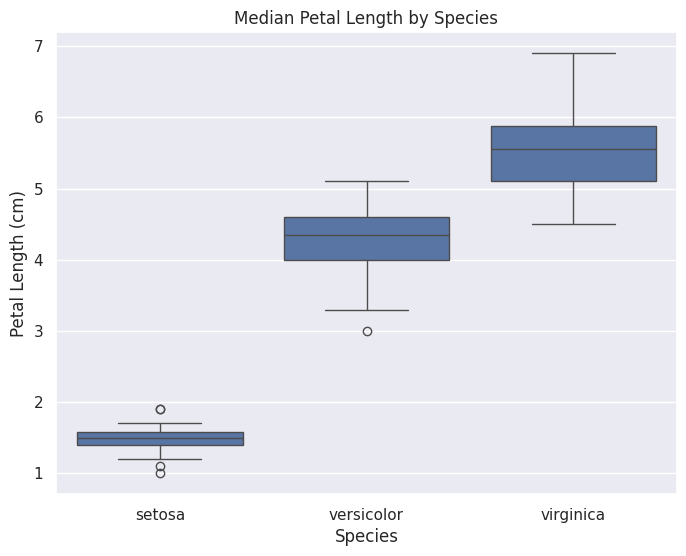

```python
# Box plot shows the median (middle line in the box)
plt.figure(figsize=(8, 6))
sns.boxplot(data=iris, x='species', y='petal_length')
plt.xlabel('Species')
plt.ylabel('Petal Length (cm)')
plt.title('Median Petal Length by Species')
plt.show()
```

## Question 2: What is the mean sepal width for each iris species?

Using the bar graphs the mean sepal width for each iris species are around 3.45 cm for serosa, 2.75 cm for versicolor, and 2.95 cm for virginica.

A bar plot was used for this question as it allows to easily display the mean of each species clearly. Not only is it a clear plot for a person to see but it makes it a very easy way to compare side by side using the naked eye the mean of each iris species. This will potentially allow the user to find any sign of trends.

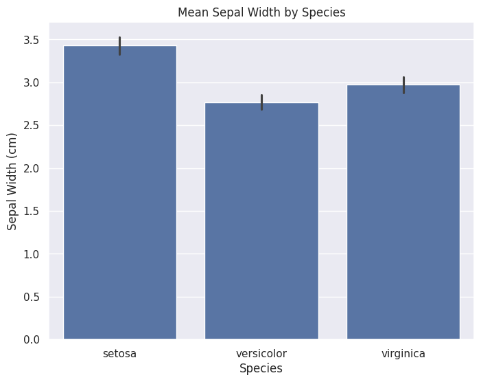

```python
# Bar plot shows the mean (height of bar)
plt.figure(figsize=(8, 6))
sns.barplot(data=iris, x='species', y='sepal_width', estimator='mean')
plt.xlabel('Species')
plt.ylabel('Sepal Width (cm)')
plt.title('Mean Sepal Width by Species')
plt.show()
```

## Question 3: Is there an association between sepal length and width?

When looking at the scatter plot between sepal length and sepal width there is a clear relationship. Each of the species all protray some sort of linear correlation between the two variables indicating that the sepal width and length are not independent.

When investigating setosa species it is clear that it had the strongest linear correlation out of the three species. It also possesed the highest slope out of all the three species indicating that the setosa's width increases much more dramtically as the length increases compared to the two others.

When investigating the versicolor length it is clear that it does have a weaker linear correlation comapred to setosa species. When looking at the scatter plot we can determine that the linear correlation of versicolor is just slightly better than the one for virginica. As some of the points from viriginica are far from the regression line.

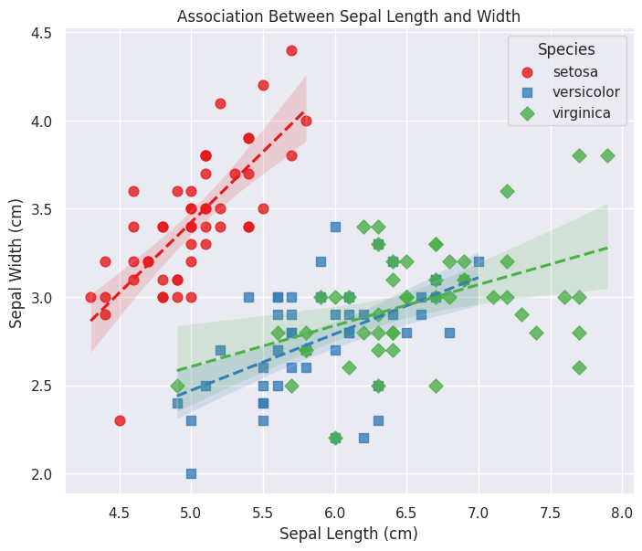

```python
# Scatter plot to visualize association between two variables

plt.figure(figsize=(8, 6))
# sns.scatterplot(data=iris, x='sepal_length', y='sepal_width', hue='species')
sns.lmplot(
    data=iris,
    x='sepal_length',
    y='sepal_width',
    hue='species',
    markers=['o', 's', 'D'],
    palette='Set1',
    height=6,
    aspect=1.2,
    legend=False,
    scatter_kws={'s': 60},  # size of scatter points
    line_kws={'linestyle':'--'}
)
plt.xlabel('Sepal Length (cm)')
plt.ylabel('Sepal Width (cm)')
plt.title('Association Between Sepal Length and Width')
plt.legend(title='Species')
plt.show()
```

## Question 4: Compare the distributions of petal width for each species.

When comparing the distribution of petal width for each of the three species it can be seen that the setosa has the lowest variance distribution with most of its points landing near the mean.

When looking at the Versicolor distribution it is clear that its variation is larger than setosa's variation showing a moderate spread from its point across the ran of 0.85 cm to 2.0 cm.

When looking at the virginica distribution it is clear that it has the highest amongst all three variations. It distribution is even distrbuted along its range, protraying a much smoother decline when reaching both ends of its distribution.

Violin plots were used in this question as they provide a very easy way to see the distribution of each of the species. Not only is it able to display the distribution but allows a very fast and easy way for the reader to make comparisons about the distributions of each species as they are clearly placed side by side. This is not the case of the box plots which do not consider the distribution but only the min, median, and max.

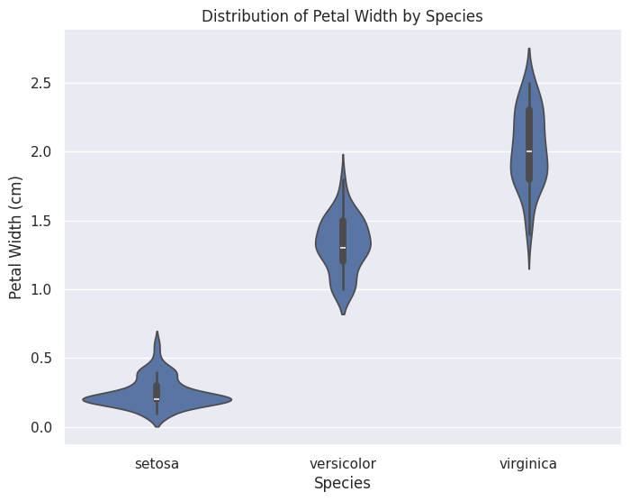

```python
# Violin plot shows the distribution of data
plt.figure(figsize=(8, 6))
sns.violinplot(data=iris, x='species', y='petal_width')
plt.xlabel('Species')
plt.ylabel('Petal Width (cm)')
plt.title('Distribution of Petal Width by Species')
plt.show()
```

## Question 5: Are there any petal length outliers?

WHen looking at the box plots we can clearly see that the setosa species was the one that contained the most amount of outliers. Setosa contained outliers from both ends of the spectrum where most of them come from the lower of its range.

When looking at the versicolor species there is only one visible outlier which is at the lower nd of its range.

When looking at the virginica box plot there are clearly no outliters present.

A box plot was used in this question as it could clearly show which species had outliers. If they were points that resided outside the box plot quartiles range they were deemed to be an outlier. Since the box plot clearly indicate those quartiles all the reader has to do is to observe the points that are way beyong those quartiles to classify them as quartile.

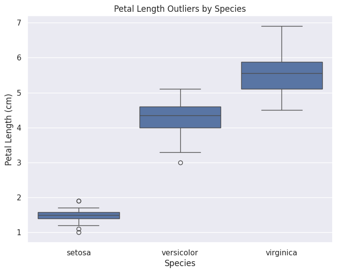

```python
# Box plot shows outliers as individual points beyond the whiskers
plt.figure(figsize=(8, 6))
sns.boxplot(data=iris, x='species', y='petal_length')
plt.xlabel('Species')
plt.ylabel('Petal Length (cm)')
plt.title('Petal Length Outliers by Species')
plt.show()
```

## Question 6: Does the association between petal and sepal width change with petal length?

Yes the association between petal and sepal width does change with petal length.

When the petal length are smaller in value there is no association between the petal width and sepal width due to the correlation appearing to be close to a vertical line rather than other function patterns.

When the petal length are 3 or larger there is a clear linear positive association between the petal and sepal width.

A scatter plot using different circle size was chosen for this question as it allows use to investigate the relationshio of 3 variables simultaneously while being able to visualize it in 2D instead of 3D. The ability to use the size of circle allows the 3rd variable that is being investigated to be accounted for and included in the 2D plot. The 2D plot allows the reader to clearly understand and make conclusions about the graph without having to go through much difficulty as it could be the case in a 3D scatter plot.

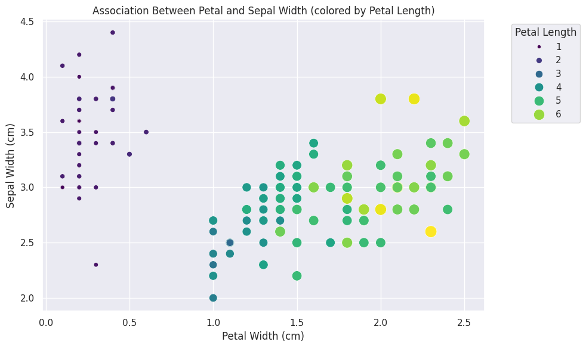

```python
# Scatter plot with color coding for petal length
plt.figure(figsize=(10, 6))
scatter = sns.scatterplot(data=iris, x='petal_width', y='sepal_width',
                          hue='petal_length', size='petal_length',
                          sizes=(20, 200), palette='viridis')
plt.xlabel('Petal Width (cm)')
plt.ylabel('Sepal Width (cm)')
plt.title('Association Between Petal and Sepal Width (colored by Petal Length)')
plt.legend(title='Petal Length', bbox_to_anchor=(1.05, 1), loc='upper left')
plt.tight_layout()
plt.show()
```